# Online-Recruiting (OR)

Pia Nolte, Anika Berghahn, Christina Koerfers

2020-01-22

# 1 First Section

## 1.1 A Subsection Sample

Please note that the first paragraph of a section or subsection is not indented. The first paragraph that follows a table, figure, equation etc. does not need an indent, either.

Subsequent paragraphs, however, are indented.

### 1.1.1 Sample Heading (Third Level)

Only two levels of headings should be numbered. Lower level headings remain unnumbered; they are formatted as run-in headings.

#### 1.1.1.1 Sample Heading (Fourth Level)

The contribution should contain no more than four levels of headings.

# 2 References

You can cite any paper in parenthesis as following (Calero Valdez, Ziefle, and Sedlmair 2017) or inline saying that Calero Valdez, Ziefle, and Sedlmair (2017) found something. Multiple citations are possible as well (Calero Valdez, Ziefle, and Sedlmair 2017; Calero Valdez and Ziefle 2019).

You can refer to other sections by kebab-casing to section 1.1. You can easily cite an r-package directly in the text by using the `cite_pkg` function from the package `rmdtemplates` (Calero Valdez 2019).

# 3 Environments

The environments ‘definition’, ‘lemma’, ‘proposition’, ‘corollary’, ‘remark’, and ‘example’ are defined in the available as well.

## 3.1 Theorems

**Theorem 1.** *This is a sample theorem. The run-in heading is set in bold, while the following text appears in italics. Definitions, lemmas, propositions, and corollaries are styled the same way.*

**Theorem 2.** *This is a second. Numbering works automatically.*

## 3.2 Equations

$$\begin{equation}
x + y = z
\end{equation}$$

## 3.3 Tables

You can get the non breaking space in RStudio by pressing ALT+SPACE. You can refer to tables by using Table 3.1.

Table 3.1: Test

| Sepal.Length | Sepal.Width | Petal.Length | Petal.Width | Species |
| --- | --- | --- | --- | --- |
| 5.1 | 3.5 | 1.4 | 0.2 | setosa |
| 4.9 | 3.0 | 1.4 | 0.2 | setosa |
| 4.7 | 3.2 | 1.3 | 0.2 | setosa |
| 4.6 | 3.1 | 1.5 | 0.2 | setosa |
| 5.0 | 3.6 | 1.4 | 0.2 | setosa |
| 5.4 | 3.9 | 1.7 | 0.4 | setosa |

```r
tribble(
  ~`Column Head A`, ~`Column Head B`,
  "a",  1:3,
  "b",  4:6
) %>% knitr::kable(caption = "A tribble example", booktabs=T, longtable=T)
```

Table 3.2: A tribble example

| Column Head A | Column Head B |
| --- | --- |
| a | 1:3 |
| b | 4:6 |

## 3.4 Figures

You can refer to tables by using Figure 3.1.

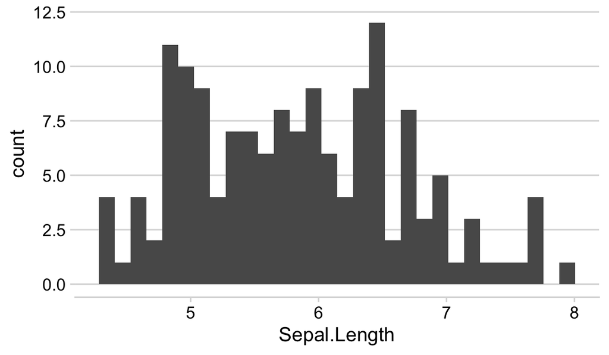

Figure 3.1: This is the text caption under the figure

```r
# Note that the label for a figure is always fig:chunkname
iris %>% ggplot() + aes(x = Sepal.Length) + geom_histogram() + cowplot::theme_minimal_hgrid()
```

# 4 Data

On this sub-page you can find the data used as a downloadable file (CSV, Excel, or PDF).

```r
data_df <- iris



datatable(data_df, filter = list(position = 'top', clear = TRUE, plain = FALSE), extensions = c('Buttons','FixedColumns'), options = list(
    dom = 'Bfrtip',
    buttons = c('copy', 'csv', 'excel', 'pdf'),
    scrollX = TRUE,
    fixedColumns = TRUE
  ))
```

|  | Sepal.Length | Sepal.Width | Petal.Length | Petal.Width | Species |
| --- | --- | --- | --- | --- | --- |
| 1 | 5.1 | 3.5 | 1.4 | 0.2 | setosa |
| 2 | 4.9 | 3 | 1.4 | 0.2 | setosa |
| 3 | 4.7 | 3.2 | 1.3 | 0.2 | setosa |
| 4 | 4.6 | 3.1 | 1.5 | 0.2 | setosa |
| 5 | 5 | 3.6 | 1.4 | 0.2 | setosa |
| 6 | 5.4 | 3.9 | 1.7 | 0.4 | setosa |
| 7 | 4.6 | 3.4 | 1.4 | 0.3 | setosa |
| 8 | 5 | 3.4 | 1.5 | 0.2 | setosa |
| 9 | 4.4 | 2.9 | 1.4 | 0.2 | setosa |
| 10 | 4.9 | 3.1 | 1.5 | 0.1 | setosa |

[output cut: 140 more lines]

```r
#rmdtemplates::line_cite(pkgs) # This creates a single line citing all packages
rmdtemplates::list_cite(pkgs) # This creates a "thightlist" of all packages
```

[output not shown]

# 5 Used Packages

# References

Barnier, Julien. 2019. *Rmdformats: HTML Output Formats and Templates for ’Rmarkdown’ Documents*. https://CRAN.R-project.org/package=rmdformats.

Calero Valdez, André. 2019. *Rmdtemplates: Rmdtemplates - an Opinionated Collection of Rmarkdown Templates*. https://github.com/statisticsforsocialscience/rmd_templates.

Calero Valdez, André, and Martina Ziefle. 2019. “The Users’ Perspective on the Privacy-Utility Trade-Offs in Health Recommender Systems.” *International Journal of Human-Computer Studies* 121. Elsevier: 108–21.

Calero Valdez, André, Martina Ziefle, and Michael Sedlmair. 2017. “Priming and Anchoring Effects in Visualization.” *IEEE Transactions on Visualization and Computer Graphics* 24 (1). IEEE: 584–94.

Revelle, William. 2019. *Psych: Procedures for Psychological, Psychometric, and Personality Research*. https://CRAN.R-project.org/package=psych.

Wickham, Hadley. 2019. *Tidyverse: Easily Install and Load the ’Tidyverse’*. https://CRAN.R-project.org/package=tidyverse.

Wickham, Hadley, and Dana Seidel. 2019. *Scales: Scale Functions for Visualization*. https://CRAN.R-project.org/package=scales.

Xie, Yihui. 2019. *Knitr: A General-Purpose Package for Dynamic Report Generation in R*. https://CRAN.R-project.org/package=knitr.

Xie, Yihui, Joe Cheng, and Xianying Tan. 2019. *DT: A Wrapper of the Javascript Library ’Datatables’*. https://CRAN.R-project.org/package=DT.